# MA5761 Homework #5

Karthik Garimella

For homework assignments in this course, you will be provided with a knitted R notebook and the .rmd file used to create it. You are *encouraged* (but not required) to use the .rmd file as a template for your solutions.

## Expected Value of Function from $\chi^2_{10}$ Distribution

Consider the problem of estimating the value of

$$\theta=\mathbb{E}\bigl(\log(1+Y)\bigr)=\int_0^\infty\log(1+y)\cdot\frac{1}{768}
y^{4}e^{-y/2}\,dy$$

when $Y$ has the $\chi^2$ distribution with $\nu=10$ degrees of freedom; note that `dchisq(y, 10)` implements the integrand factor $y^4e^{-y/2}/768$ in the above expression.

You are tasked with estimating the value of $\theta$ using various different Monte Carlo estimators. For each of these methods, you should calculate…

- the point estimate $\hat\theta$
- the estimated variance of the Monte Carlo estimator (up to the factor $1/N$)
- the estimated standard error of the Monte Carlo estimator
- a large-sample 95% confidence interval on $\theta$

Estimators should be constructed from a sample of a *total* of $N=10^4$ points.

### Simple Monte Carlo estimator

Use the simple Monte Carlo estimator with $N=10^4$ points sampled from the $\chi^2_{10}$ distribution to estimate this expected value.

###### Assigning sample number, degree of freedom and generating random samples from the $\chi^2_{10}$

```r
n <- 10^4
df <- 10
y <- rchisq(n, df)

smc <- log(1 + y)
```

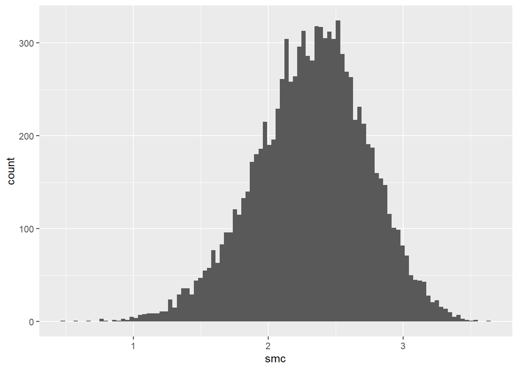

```r
library(ggplot2)

hist_smc <- ggplot(NULL) +
  geom_histogram(aes(smc), bins = 100)

hist_smc
```

###### Getting Mean, Variance and Standard Deviation using the Simple Monte Carlo method

```r
q1_mean <- mean(smc)

q1_var <- var(smc)

q1_sd <- sd(smc)
```

###### 95% Confidence Interval for Simple Monte Carlo

```r
z <- qnorm(0.95)

ci_smc <- mean(smc) + c(-1, 1) * z * sd(smc)/sqrt(n)
names(ci_smc) <- c('LowerCI', 'UpperCI')

print(q1_ci <- c(ci_smc))
```

```
##  LowerCI  UpperCI
## 2.310316 2.324009
```

### Antithetic Variables

Generate two antithetic samples (each of size $N/2$, for a total of $N$ points in the two samples) from the $\chi^2_{10}$ distribution, and use these to estimate $\theta$.

```r
n <- 10^4
df <- 10
u <- runif(n/2)
```

###### Quantile Function for the $\chi^2_{10}$ distribution

```r
u1 <- qchisq(u, df)
u2 <- qchisq((1 - u), df)
```

```r
avu1 <- log(1 + u1) #u

avu2 <- log(1 + u2) # 1 - u
```

###### Getting Mean, Variance and Standard Deviation using the Antithetic Variables

```r
avu <- (avu1 + avu2) * 0.5

q2_mean <- mean(avu)

q2_var <- var(avu)

q2_sd <- sd(avu)
```

###### 95% Confidence Interval for Antithetic Variables

```r
z <- qnorm(0.95)

# smc 95% CI
ci_avu <- mean(avu) + c(-1, 1) * z * sd(avu)/sqrt(n)
names(ci_avu) <- c('LowerCI', 'UpperCI')
print(q2_ci <- c(ci_avu))
```

```
##  LowerCI  UpperCI
## 2.314610 2.315542
```

### Single Control Variable

It is known that
$$\mathbb{E}\left(\sqrt{Y}\right)=\frac{\Gamma(\frac{\nu}{2}+\frac12)}{\Gamma(\frac{\nu}2)}\,\sqrt{2}$$
when $Y\sim\chi^2_{\nu}$. Note that the $\Gamma$ function is implemented in R with `gamma()`.

Estimate $\theta$ by sampling from the $\chi^2_{10}$ distribution and using a single control variable $\sqrt{Y}$. Estimate the optimal coefficient attached to the control variable *without using the lm()* function. $$

```r
n <- 10^4
df <- 10
y <- rchisq(n, df)

gx <- log(1 + y)
```

###### Gamma function for $$\mathbb{E}\left(\sqrt{Y}\right)$$

```r
scv <- (gamma(df/2 + 1/2)/gamma(df/2)) * sqrt(2)

y1 = sqrt(y)
```

###### Getting value of the optimal coefficient C

```r
print(C <- -1*cov(gx, y1) / var(y1))
```

```
## [1] -0.5892989
```

```r
mc_lm <- lm(log(1 + y) ~ y1)
summary(mc_lm)
```

```
##
## Call:
## lm(formula = log(1 + y) ~ y1)
##
## Residuals:
##      Min       1Q   Median       3Q      Max
## -0.49575 -0.01304  0.01921  0.03291  0.03669
##
## Coefficients:
##              Estimate Std. Error t value Pr(>|t|)
## (Intercept) 0.4983561  0.0022982   216.8   <2e-16 ***
## y1          0.5892989  0.0007271   810.5   <2e-16 ***
## ---
## Signif. codes:  0 '***' 0.001 '**' 0.01 '*' 0.05 '.' 0.1 ' ' 1
##
## Residual standard error: 0.05024 on 9998 degrees of freedom
## Multiple R-squared:  0.985,  Adjusted R-squared:  0.985
## F-statistic: 6.569e+05 on 1 and 9998 DF,  p-value: < 2.2e-16
```

###### Getting value of the optimal coefficient C from the lm() function

```r
print(C_LM <- -1*coef(mc_lm)[-1])
```

```
##         y1
## -0.5892989
```

###### Getting Mean, Variance and Standard Deviation using the Single Control Variable

```r
phi <- c(scv)

gx_control <- gx + C * (y1 - scv)

print(mc_control <- mean(gx_control))
```

```
## [1] 2.315947
```

```r
q3_mean <- mean(gx_control)

q3_var <- var(gx_control)

q3_sd <- sd(gx_control)

# Estimating variance from the linear model
sigma(mc_lm)^2
```

```
## [1] 0.002524378
```

###### 95% Confidence Interval for Single Control Variables

```r
print(q3_ci <- mc_control + c(-1, 1) * qnorm(.95) * sd(gx_control)/sqrt(n))
```

```
## [1] 2.315121 2.316774
```

###### Using lm() for 95% CI and predict() function as well

```r
mc_control + c(-1, 1) * qnorm(.95) * sigma(mc_lm)/sqrt(n)
```

```
## [1] 2.315121 2.316774
```

```r
predict(mc_lm, data.frame(y1 = 3.084328), interval = 'confidence')
```

```
##        fit      lwr      upr
## 1 2.315947 2.314962 2.316932
```

###### Variance Reduction

```r
100 * (var(y) - var(gx_control)) / var(y)
```

```
## [1] 99.98711
```

### Several Control Variables

In general, it can be shown that
$$\mathbb{E}\left(Y^k\right)=\frac{\Gamma(\frac{\nu}{2}+k)}{\Gamma(\frac{\nu}2)}\,2^{k}$$
whenever $Y\sim\chi^2_{\nu}$ and $k>-\nu/2$.

Estimate $\theta$ by sampling from the $\chi^2_{10}$ distribution and using several control variables: $\sqrt{Y}$, $Y$, and $1/Y$. Here, you *should* use the `lm()` and associated functions to estimate the optimal coefficients on the control variables, the point estimate $\hat\theta$ and the variance $\hat\sigma^2$.

```r
n <- 10^4
df <- 10
y <- rchisq(n, df)
```

###### Several Variables

```r
sqrt_y <- (gamma(df/2 + 1/2) / gamma(df/2)) * 2^(1/2)
sqrt_y
```

```
## [1] 3.084328
```

```r
normal_y <- (gamma(df/2 + 1) / gamma(df/2)) * 2
normal_y
```

```
## [1] 10
```

```r
inv_y <- (gamma(df/2 - 1) / gamma(df/2)) * (1/2)
inv_y
```

```
## [1] 0.125
```

```r
y1 <- sqrt(y)
y2 <- y
y3 <- 1/y

mc_lm <- lm(log(1 + y) ~ y1 + y2 + y3)
summary(mc_lm)
```

```
##
## Call:
## lm(formula = log(1 + y) ~ y1 + y2 + y3)
##
## Residuals:
##       Min        1Q    Median        3Q       Max
## -0.009118 -0.002417  0.000508  0.002346  0.099946
##
## Coefficients:
##               Estimate Std. Error t value Pr(>|t|)
## (Intercept)  0.0663909  0.0017971   36.94   <2e-16 ***
## y1           0.9344805  0.0008608 1085.62   <2e-16 ***
## y2          -0.0591267  0.0001111 -531.99   <2e-16 ***
## y3          -0.3371248  0.0020310 -165.99   <2e-16 ***
## ---
## Signif. codes:  0 '***' 0.001 '**' 0.01 '*' 0.05 '.' 0.1 ' ' 1
##
## Residual standard error: 0.004116 on 9996 degrees of freedom
## Multiple R-squared:  0.9999, Adjusted R-squared:  0.9999
## F-statistic: 3.338e+07 on 3 and 9996 DF,  p-value: < 2.2e-16
```

###### Getting optimal coefficient

```r
print(C <- -1*coef(mc_lm)[-1])
```

```
##          y1          y2          y3
## -0.93448050  0.05912671  0.33712479
```

```r
phi <- c(sqrt_y, normal_y, inv_y)
gx_control <- log(1 + y) + C[1]*(y1-phi[1]) + C[2]*(y2-phi[2]) + C[3]*(y3-phi[3])

print(mc_control <- mean(gx_control))
```

```
## [1] 2.315227
```

###### Getting Mean, Variance and Standard Deviation using the Several Control Variables

```r
q4_mean <- mean(gx_control)

q4_var <- var(gx_control)

q4_sd <- sd(gx_control)

# Estimating variance from the linear model
sigma(mc_lm)^2
```

```
## [1] 1.694022e-05
```

###### 95% Confidence Interval for Several Control Variables

```r
mc_control + c(-1, 1) * qnorm(.95) * sd(gx_control)/sqrt(n)
```

```
## [1] 2.315160 2.315295
```

```r
print(q4_ci <- mc_control + c(-1, 1) * qnorm(.95) * sd(gx_control)/sqrt(n))
```

```
## [1] 2.315160 2.315295
```

###### Using lm() output for 95% CI

```r
mc_control + c(-1, 1) * qnorm(.95) * sigma(mc_lm)/sqrt(n)
```

```
## [1] 2.315160 2.315295
```

###### Using in-built predict() function for getting the CI interval

```r
predict(mc_lm, data.frame(y1 = 3.084328, y2 = 10, y3 = 1.090475), interval = 'confidence')
```

```
##        fit      lwr      upr
## 1 1.989742 1.985897 1.993587
```

###### Variance Reduction

```r
100 * (var(y) - var(gx_control)) / var(y)
```

```
## [1] 99.99991
```

### Importance Sampling with the Maximum Principle

Suppose that we wish to use importance sampling, sampling from a $\mathsf{Gamma}(\alpha,\beta)$ distribution. Recall that the *mode*, $\tilde\mu$, of this gamma distribution is given by the equation
$$\tilde\mu=(\alpha-1)\beta$$

Use the Maximum Principle to determine the value of $\alpha$ (the *shape* parameter) if we choose to use $\beta=2$ (recall this is the *scale* parameter). Sample from this gamma distribution using importance sampling.

###### Assigning Beta = 2

```r
n <- 10^4
df <- 10
y <-  rchisq(n, df)
beta <- 2
```

```r
g <- function(y) log(1+y) * dchisq(y, 10)
```

###### Plot for ‘g’ function

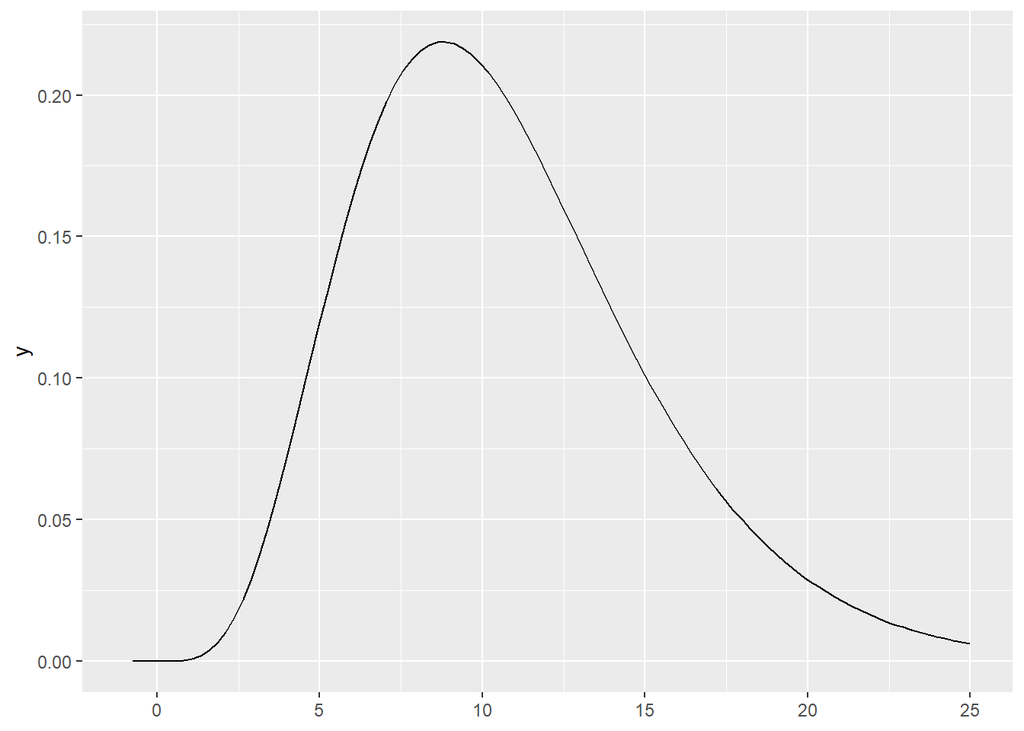

```r
library(ggplot2)

mc_g_plot <- ggplot(NULL) +
  xlim(-1,25) +
  geom_function(fun = g)
mc_g_plot
```

###### Finding the x-location of the maximum value a.k.a Mode

```r
gmax <- optimize(g, c(0, 25), maximum = TRUE)
gmax
```

```
## $maximum
## [1] 8.787192
##
## $objective
## [1] 0.2188085
```

```r
m <- gmax$maximum
```

###### Finding Alpha value from the Mode and Beta

```r
alpha <- (m/beta) + 1

alpha
```

```
## [1] 5.393596
```

###### Plot for g(x)/fX(x)

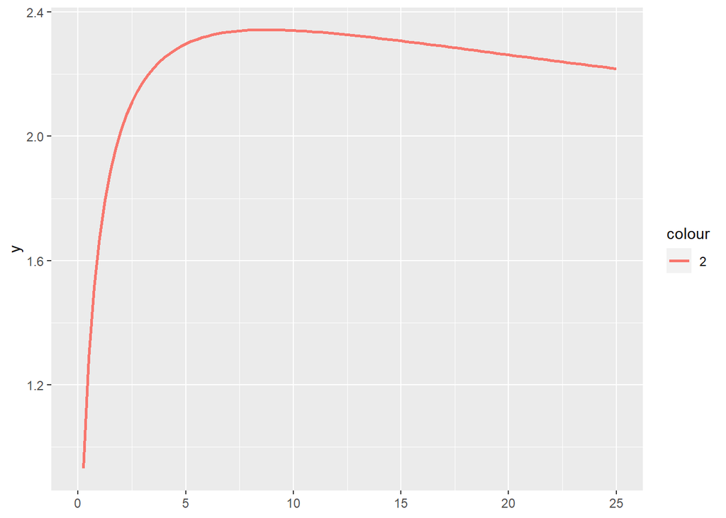

```r
gammarat <- function(y) g(y)/dgamma(y, shape = alpha, scale = beta)

ggplot(NULL) +
  xlim(0, 25) +
  geom_function(aes(col = '2'), fun = function(y) gammarat(y), linewidth = 1)
```

```r
is_mp <- gammarat(y)
```

###### Getting Mean, Variance and Standard Deviation using the Importance Sampling with Maximum Principle

```r
q5_mean <- mean(is_mp)

q5_var <- var(is_mp)

q5_sd <- sd(is_mp)
```

###### 95% Confidence Interval for Importance Sampling with Maximum Principle

```r
z <- qnorm(.95)

is_mp_ci <- mean(is_mp) + c(-1, 1) * z * sd(is_mp)/sqrt(n)
names(is_mp_ci) <- c('LowerCI', 'UpperCI')

print(q5_ci <- is_mp_ci)
```

```
##  LowerCI  UpperCI
## 2.312344 2.313957
```

### Stratified Importance Sampling

Suppose that we choose to use stratified importance sampling to estimate $\theta$. Particularly, suppose that we split the interval of integration into the two subinterval $(0,8)$ and $(8,\infty)$. Sample from…

- the $\mathsf{Gamma}(\alpha=6.1, \beta=1.6)$ distribution, truncated to the interval $(0,8)$
- and the $\mathsf{Gamma}(\alpha=5.35, \beta=2)$ distribution, truncated to the interval $(8,\infty)$

Obtain some smaller samples from these two distributions to get variance estimates that allow you to estimate the optimal value of $p$ that minimizes the variance of the stratified importance sampling estimator. Once this initial estimate is made, sample $pN$ points from the first distribution and $(1-p)N$ points from the second distribution. Use these to obtain the point estimate $\hat\theta$ and other requested quantities.

###### Gamma density function as well as Random Sample Generation for the Gamma distribution

```r
dgamma_trunc <- function(x, shape, scale, a, b) {
  p <- pgamma(b, shape, 1/scale) - pgamma(a, shape, 1/scale)
  return(dgamma(x, shape, 1/scale) / p * (a<=x & x<=b))
}

rgamma_trunc <- function(n, shape, scale, a, b) {
  p <- pgamma(c(a, b), shape, 1/scale)
  u <- runif(n, p[1], p[2])
  return(qgamma(u, shape, 1/scale))
}
```

###### Defining f1 and f2 with the intervals from (0,8) to (8,Inf)

```r
f1 <- function(x) dgamma_trunc(x, 6.1, 1.6, 0, 8)
f2 <- function(x) dgamma_trunc(x, 5.35, 2, 8, Inf)
```

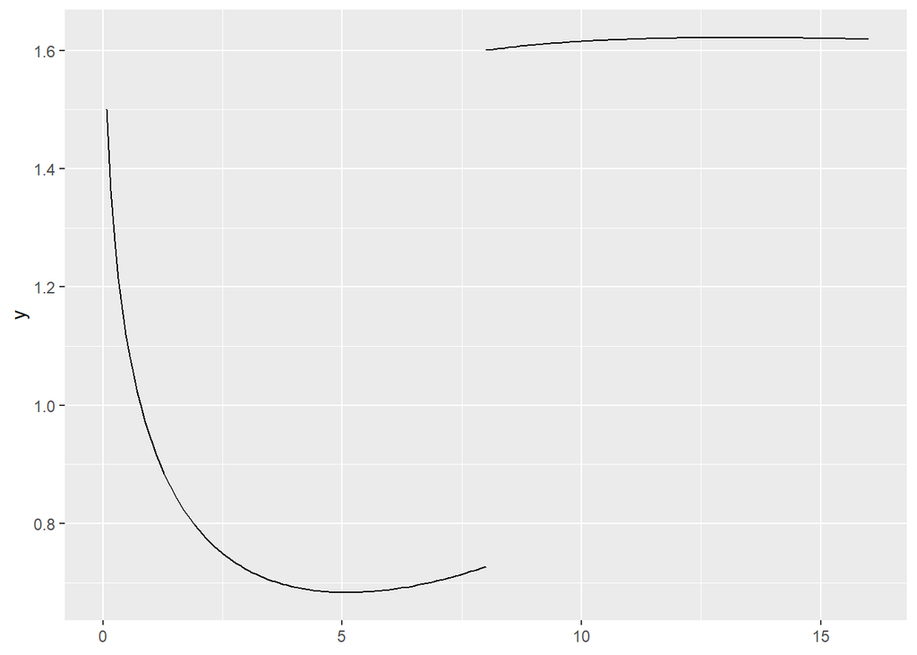

```r
ggplot(NULL) +
  geom_function(fun = function(x) g(x)/f1(x), xlim = c(0, 8)) +
  geom_function(fun = function(x) g(x)/f2(x), xlim = c(8, 16))
```

###### Defining x1 and x2 for smaller samples

```r
x1 <- rgamma_trunc(1000, 6.1, 1.6, 0, 8)
gx1 <- g(x1) / f1(x1)
print(v1 <- var(gx1))
```

```
## [1] 0.0002558455
```

```r
x2 <- rgamma_trunc(1000, 5.35, 2, 8, Inf)
gx2 <- g(x2) / f2(x2)
print(v2 <- var(gx2))
```

```
## [1] 4.71392e-05
```

###### Optimal choice for p

```r
print(p <- sd(gx2) / (sd(gx1)+sd(gx2)))
```

```
## [1] 0.3003284
```

```r
N <- 10^6
p <- round(p, 3)
```

###### Random Samples for pN and (1-p)N samples

```r
x1 <- rgamma_trunc(p*N, 6.1, 1.6, 0, 8)
x2 <- rgamma_trunc((1-p)*N, 5.35, 2, 8, Inf)
```

###### Mean for gx1 and gx2

```r
gx1 <- g(x1) / f1(x1)
mean(gx1)
```

```
## [1] 0.7000503
```

```r
gx2 <- g(x2) / f2(x2)
mean(gx2)
```

```
## [1] 1.615111
```

###### Getting Mean, Variance and Standard Deviation using the Stratified Importance Sampling

```r
print(mc_est <- mean(gx1) + mean(gx2))
```

```
## [1] 2.315161
```

```r
q6_mean <- mc_est
```

```r
print(mc_var <- var(gx1)/p + var(gx2)/(1-p))
```

```
## [1] 0.001077349
```

```r
q6_var <- mc_var
```

```r
print(mc_stderr <- sqrt(mc_var)/sqrt(N))
```

```
## [1] 3.2823e-05
```

```r
q6_sd <- mc_stderr
```

###### 95% Confidence Interval for Stratified Importance Sampling

```r
print(mc_ci <- mc_est + c(-1, 1) * qnorm(.95) * mc_stderr)
```

```
## [1] 2.315107 2.315215
```

```r
print(q6_ci <- mc_ci)
```

```
## [1] 2.315107 2.315215
```

```r
integrate(g, 0, 10^4)
```

```
## 2.315204 with absolute error < 6e-06
```

### Comparisons

Create a table of all of the quantities from your above estimators. The columns of this table should include…

- a short descriptive name of the estimator used
- the value of the point estimate $\hat\theta$
- the estimated variance of the estimator (after removing the $1/N$ factor)
- the estimated % reduction in variance from the simple Monte Carlo estimator (so this should be 0 for the row corresponding to the simple Monte Carlo estimator)
- the estimated standard error of the estimator
- the large-sample 95% confidence interval on $\theta$

###### Creating matrix to store the data

```r
data = matrix(, ncol = 7, nrow = 6, byrow=TRUE)

colnames(data) = c('Short Description','Point Estimate θ^',
                   'Estimated Variance','Estimated % Reduction',
                   'Estimated Standard Error','95% Confidence Interval - Lwr. CI',
                   '95% Confidence Interval - Upr. CI')
rownames(data) <- c('row1','row2','row3','row4','row5','row6')
```

```r
data[1,1] <- 'Simple Monte Carlo'
data[2,1] <- 'Antithetic Variables'
data[3,1] <- 'Single Control Variable'
data[4,1] <- 'Several Control Variables'
data[5,1] <- 'Importance Sampling with the Maximum Principle'
data[6,1] <- 'Stratified Importance Sampling'

data[1,2] <- q1_mean
data[2,2] <- q2_mean
data[3,2] <- q3_mean
data[4,2] <- q4_mean
data[5,2] <- q5_mean
data[6,2] <- q6_mean

data[1,3] <- q1_var
data[2,3] <- q2_var
data[3,3] <- q3_var
data[4,3] <- q4_var
data[5,3] <- q5_var
data[6,3] <- q6_var

data[1,4] <- 100 * (1 - q1_var/q1_var)
data[2,4] <- 100 * (1 - q2_var/q1_var)
data[3,4] <- 100 * (1 - q3_var/q1_var)
data[4,4] <- 100 * (1 - q4_var/q1_var)
data[5,4] <- 100 * (1 - q5_var/q1_var)
data[6,4] <- 100 * (1 - q6_var/q1_var)

data[1,5] <- q1_sd
data[2,5] <- q2_sd
data[3,5] <- q3_sd
data[4,5] <- q4_sd
data[5,5] <- q5_sd
data[6,5] <- q6_sd

data[1,6] <- q1_ci[1]
data[2,6] <- q2_ci[1]
data[3,6] <- q3_ci[1]
data[4,6] <- q4_ci[1]
data[5,6] <- q5_ci[1]
data[6,6] <- q6_ci[1]

data[1,7] <- q1_ci[1]
data[2,7] <- q2_ci[1]
data[3,7] <- q3_ci[1]
data[4,7] <- q4_ci[1]
data[5,7] <- q5_ci[1]
data[6,7] <- q6_ci[1]
```

###### Using the ‘knitr’ library to beautify the matrix into a table

```r
#cbind(data)
library(knitr)

kable(data, format = "markdown")
```

|  | Short Description | Point Estimate θ^ | Estimated Variance | Estimated % Reduction | Estimated Standard Error | 95% Confidence Interval - Lwr. CI | 95% Confidence Interval - Upr. CI |
| --- | --- | --- | --- | --- | --- | --- | --- |
| row1 | Simple Monte Carlo | 2.3171623302392 | 0.17324261726246 | 0 | 0.416224239157764 | 2.31031605074516 | 2.31031605074516 |
| row2 | Antithetic Variables | 2.31507639384721 | 0.000802544627341029 | 99.5367510373471 | 0.0283292186150806 | 2.31461041966733 | 2.31461041966733 |
| row3 | Single Control Variable | 2.31594712863568 | 0.00252412548155063 | 98.543011228163 | 0.050240675568215 | 2.31512074306139 | 2.31512074306139 |
| row4 | Several Control Variables | 2.31522740484998 | 1.69351411780836e-05 | 99.9902246101764 | 0.00411523282185633 | 2.31515971529365 | 2.31515971529365 |
| row5 | Importance Sampling with the Maximum Principle | 2.31315030010774 | 0.00240531237878151 | 98.6115931421554 | 0.0490439841242686 | 2.31234359835607 | 2.31234359835607 |
| row6 | Stratified Importance Sampling | 2.31516127475628 | 0.00107734906625384 | 99.3781269971108 | 3.28229959975295e-05 | 2.31510728573227 | 2.31510728573227 |

### Make a set of comments comparing these different methods. Which one appears to achieve the greatest reduction in variance?

#### Several Control Variable looks like it achieved the highest variance reduction. Stratified Sampling seems to have a great variance reduction with the Antithetic Variables achieving a great reduction as well. The single control variable shows the lowest variance reduction among all the estimation methods in the above table as we are only using a single variable for estimation.